# 0.1.1: INTENT

# 0.1.2: Goal

The goal of this project is to understand how customers feel about Amazon Echos in general, and to identify specific features or aspects of Amazon Echos that customers are particularly happy or unhappy with. The findings of this project could be used by Amazon to improve the design and functionality of Amazon Echos, and to better understand the needs of their customers.

# 0.1.3: SOURCE

data source: https://www.kaggle.com/sid321axn/amazon-alexa-reviews/kernels

# 1.0: Install & Import Packages

## 1.1: Install jupyterthemes

```python
!pip install jupyterthemes
```

```
     ━━━━━━━━━━━━━━━━━━━━━━━━━━━━━━━━━━━━━━━━ 7.0/7.0 MB 54.8 MB/s eta 0:00:00
     ━━━━━━━━━━━━━━━━━━━━━━━━━━━━━━━━━━━━━━━━ 46.7/46.7 kB 3.3 MB/s eta 0:00:00
     ━━━━━━━━━━━━━━━━━━━━━━━━━━━━━━━━━━━━━━━━ 49.6/49.6 kB 4.6 MB/s eta 0:00:00
```

## 1.2: Import Packages

```python
import pandas as pd
import numpy as np
import seaborn as sns
import matplotlib.pyplot as plt
from jupyterthemes import jtplot
jtplot.style(theme='monokai', context='notebook', ticks=True, grid=False)
# setting the style of the notebook to be monokai theme
# this line of code is important to ensure that we are able to see the x and y axes clearly
# If you don't run this code line, you will notice that the xlabel and ylabel on any plot is black on black and it will be hard to see them.
```

# 2.0: IMPORT DATA AND PERFORM EXPLORATORY DATA ANALYSIS

## 2.1: Import Data

```python
# Load the data
reviews_df = pd.read_csv('/kaggle/input/amazon-reviews/amazon_reviews.csv')
reviews_df
```

|  | rating | date | variation | verified_reviews | feedback |
| --- | --- | --- | --- | --- | --- |
| 0 | 5 | 31-Jul-18 | Charcoal Fabric | Love my Echo! | 1 |
| 1 | 5 | 31-Jul-18 | Charcoal Fabric | Loved it! | 1 |
| 2 | 4 | 31-Jul-18 | Walnut Finish | Sometimes while playing a game, you can answer... | 1 |
| 3 | 5 | 31-Jul-18 | Charcoal Fabric | I have had a lot of fun with this thing. My 4 ... | 1 |
| 4 | 5 | 31-Jul-18 | Charcoal Fabric | Music | 1 |
| ... | ... | ... | ... | ... | ... |
| 3145 | 5 | 30-Jul-18 | Black Dot | Perfect for kids, adults and everyone in betwe... | 1 |
| 3146 | 5 | 30-Jul-18 | Black Dot | Listening to music, searching locations, check... | 1 |
| 3147 | 5 | 30-Jul-18 | Black Dot | I do love these things, i have them running my... | 1 |
| 3148 | 5 | 30-Jul-18 | White Dot | Only complaint I have is that the sound qualit... | 1 |
| 3149 | 4 | 29-Jul-18 | Black Dot | Good | 1 |

3150 rows × 5 columns

## 2.2.1: Exploratory analysis (View the DataFrame Information)

```python
reviews_df.info()
```

```
<class 'pandas.core.frame.DataFrame'>
RangeIndex: 3150 entries, 0 to 3149
Data columns (total 5 columns):
 #   Column            Non-Null Count  Dtype
---  ------            --------------  -----
 0   rating            3150 non-null   int64
 1   date              3150 non-null   object
 2   variation         3150 non-null   object
 3   verified_reviews  3150 non-null   object
 4   feedback          3150 non-null   int64
dtypes: int64(2), object(3)
memory usage: 123.2+ KB
```

## 2.2.2: Exploratory analysis (View DataFrame Statistical Summary)

```python
reviews_df.describe()
```

|  | rating | feedback |
| --- | --- | --- |
| count | 3150.000000 | 3150.000000 |
| mean | 4.463175 | 0.918413 |
| std | 1.068506 | 0.273778 |
| min | 1.000000 | 0.000000 |
| 25% | 4.000000 | 1.000000 |
| 50% | 5.000000 | 1.000000 |
| 75% | 5.000000 | 1.000000 |
| max | 5.000000 | 1.000000 |

## 2.2.3: Exploratory analysis (Plot the count plot for the ratings)

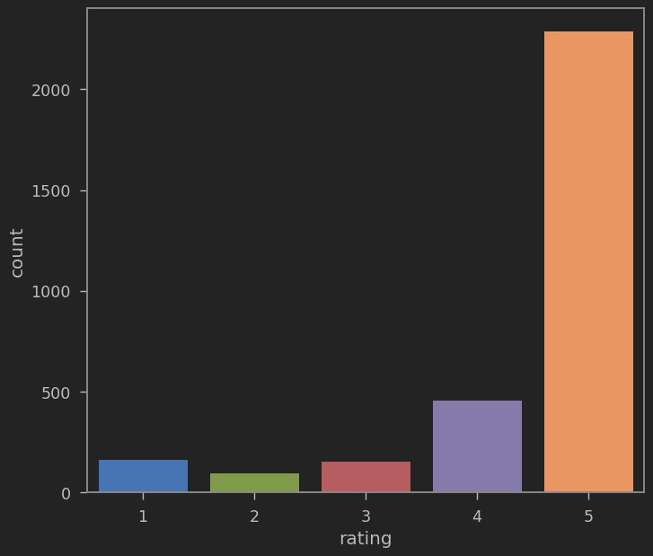

```python
sns.countplot(x = reviews_df['rating'])
```

## 2.2.4: Exploratory analysis (Length of the verified_reviews column)

```python
reviews_df['length'] = reviews_df['verified_reviews'].apply(len)
```

```python
reviews_df
```

|  | rating | date | variation | verified_reviews | feedback | length |
| --- | --- | --- | --- | --- | --- | --- |
| 0 | 5 | 31-Jul-18 | Charcoal Fabric | Love my Echo! | 1 | 13 |
| 1 | 5 | 31-Jul-18 | Charcoal Fabric | Loved it! | 1 | 9 |
| 2 | 4 | 31-Jul-18 | Walnut Finish | Sometimes while playing a game, you can answer... | 1 | 195 |
| 3 | 5 | 31-Jul-18 | Charcoal Fabric | I have had a lot of fun with this thing. My 4 ... | 1 | 172 |
| 4 | 5 | 31-Jul-18 | Charcoal Fabric | Music | 1 | 5 |
| ... | ... | ... | ... | ... | ... | ... |
| 3145 | 5 | 30-Jul-18 | Black Dot | Perfect for kids, adults and everyone in betwe... | 1 | 50 |
| 3146 | 5 | 30-Jul-18 | Black Dot | Listening to music, searching locations, check... | 1 | 135 |
| 3147 | 5 | 30-Jul-18 | Black Dot | I do love these things, i have them running my... | 1 | 441 |
| 3148 | 5 | 30-Jul-18 | White Dot | Only complaint I have is that the sound qualit... | 1 | 380 |
| 3149 | 4 | 29-Jul-18 | Black Dot | Good | 1 | 4 |

3150 rows × 6 columns

## 2.2.5: Exploratory analysis (Plot the histogram for the length)

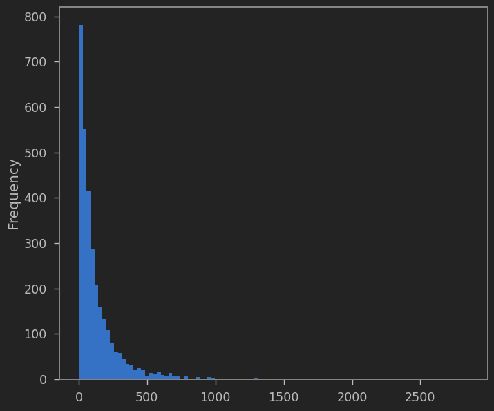

```python
reviews_df['length'].plot(bins=100, kind='hist')
```

## 2.2.6: Exploratory analysis (Apply the describe method to get statistical summary)

```python
reviews_df.describe()
```

|  | rating | feedback | length |
| --- | --- | --- | --- |
| count | 3150.000000 | 3150.000000 | 3150.000000 |
| mean | 4.463175 | 0.918413 | 132.049524 |
| std | 1.068506 | 0.273778 | 182.099952 |
| min | 1.000000 | 0.000000 | 1.000000 |
| 25% | 4.000000 | 1.000000 | 30.000000 |
| 50% | 5.000000 | 1.000000 | 74.000000 |
| 75% | 5.000000 | 1.000000 | 165.000000 |
| max | 5.000000 | 1.000000 | 2851.000000 |

## 2.2.7: Exploratory analysis (Plot the countplot for feedback)

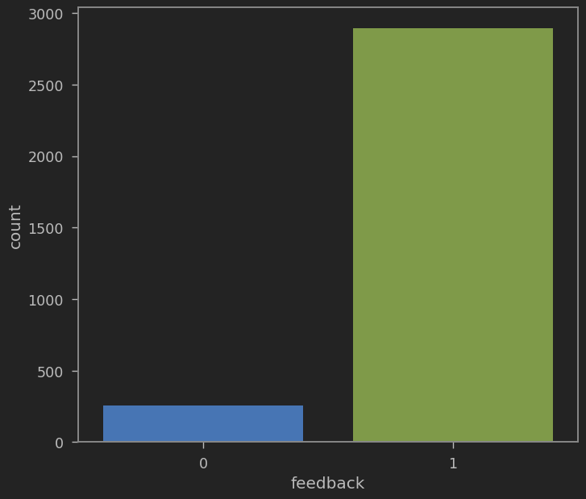

```python
sns.countplot(x = reviews_df['feedback'])
```

## 3.0.0: Plot Wordlcloud

### 3.1.1 New dataset named positive in which the feedback is 1, or positive.

```python
# Obtain only the positive reviews
positive = reviews_df[reviews_df['feedback'] == 1]
positive
```

|  | rating | date | variation | verified_reviews | feedback | length |
| --- | --- | --- | --- | --- | --- | --- |
| 0 | 5 | 31-Jul-18 | Charcoal Fabric | Love my Echo! | 1 | 13 |
| 1 | 5 | 31-Jul-18 | Charcoal Fabric | Loved it! | 1 | 9 |
| 2 | 4 | 31-Jul-18 | Walnut Finish | Sometimes while playing a game, you can answer... | 1 | 195 |
| 3 | 5 | 31-Jul-18 | Charcoal Fabric | I have had a lot of fun with this thing. My 4 ... | 1 | 172 |
| 4 | 5 | 31-Jul-18 | Charcoal Fabric | Music | 1 | 5 |
| ... | ... | ... | ... | ... | ... | ... |
| 3145 | 5 | 30-Jul-18 | Black Dot | Perfect for kids, adults and everyone in betwe... | 1 | 50 |
| 3146 | 5 | 30-Jul-18 | Black Dot | Listening to music, searching locations, check... | 1 | 135 |
| 3147 | 5 | 30-Jul-18 | Black Dot | I do love these things, i have them running my... | 1 | 441 |
| 3148 | 5 | 30-Jul-18 | White Dot | Only complaint I have is that the sound qualit... | 1 | 380 |
| 3149 | 4 | 29-Jul-18 | Black Dot | Good | 1 | 4 |

2893 rows × 6 columns

### 3.1.2 New dataset named negative in which the feedback is 0, or negative.

```python
# Obtain the negative reviews only
negative = reviews_df[reviews_df['feedback'] == 0]
negative
```

|  | rating | date | variation | verified_reviews | feedback | length |
| --- | --- | --- | --- | --- | --- | --- |
| 46 | 2 | 30-Jul-18 | Charcoal Fabric | It's like Siri, in fact, Siri answers more acc... | 0 | 163 |
| 111 | 2 | 30-Jul-18 | Charcoal Fabric | Sound is terrible if u want good music too get... | 0 | 53 |
| 141 | 1 | 30-Jul-18 | Charcoal Fabric | Not much features. | 0 | 18 |
| 162 | 1 | 30-Jul-18 | Sandstone Fabric | Stopped working after 2 weeks ,didn't follow c... | 0 | 87 |
| 176 | 2 | 30-Jul-18 | Heather Gray Fabric | Sad joke. Worthless. | 0 | 20 |
| ... | ... | ... | ... | ... | ... | ... |
| 3047 | 1 | 30-Jul-18 | Black Dot | Echo Dot responds to us when we aren't even ta... | 0 | 120 |
| 3048 | 1 | 30-Jul-18 | White Dot | NOT CONNECTED TO MY PHONE PLAYLIST :( | 0 | 37 |
| 3067 | 2 | 30-Jul-18 | Black Dot | The only negative we have on this product is t... | 0 | 240 |
| 3091 | 1 | 30-Jul-18 | Black Dot | I didn’t order it | 0 | 17 |
| 3096 | 1 | 30-Jul-18 | White Dot | The product sounded the same as the emoji spea... | 0 | 210 |

257 rows × 6 columns

### 3.2.0 Convert the strings from the 'verified_reviews' column from the 'positive' dataset to a list:

```python
# Convert to list format
sentences = positive['verified_reviews'].tolist()
len(sentences)
```

```
2893
```

### 3.2.1 # Join all reviews into one large string

```python
sentences_as_one_string =" ".join(sentences)
```

```python
sentences_as_one_string
```

```
'Love my Echo! Loved it! Sometimes while playing a game, you can answer a question correctly but Alexa says you got it wrong and answers the same as you.  I like being able to turn lights on and off while away from home. I have had a lot of fun with this thing. My 4 yr old learns about dinosaurs, i …
```

### 3.3.0 Create a word cloud image for positive reviews with a width of 20 inches and a height of 20 inches.

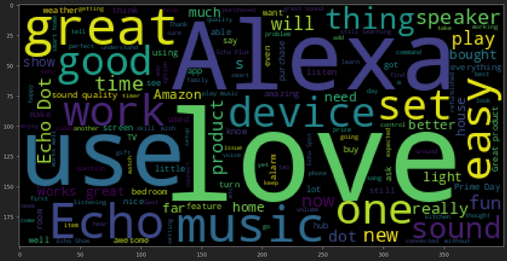

```python
!pip install wordcloud

from wordcloud import WordCloud

plt.figure(figsize=(20,20))
plt.imshow(WordCloud().generate(sentences_as_one_string))
```

### 3.3.1 Create a word cloud image for negative reviews with a width of 20 inches and a height of 20 inches.

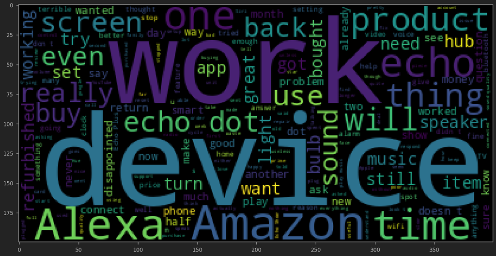

```python
sentences = negative['verified_reviews'].tolist()
len(sentences)
sentences_as_one_string =" ".join(sentences)
plt.figure(figsize = (20,20))
plt.imshow(WordCloud().generate(sentences_as_one_string))
```

# 4.0.0 Perform Data cleaning.

### 4.1.0 Import String and nltk

```python
import string
string.punctuation
```

```
'!"#$%&\'()*+,-./:;<=>?@[\\]^_`{|}~'
```

```python
import nltk # Natural Language tool kit
nltk.download('stopwords')

# You have to download stopwords Package to execute this command
from nltk.corpus import stopwords
stopwords.words('english')
```

[output not shown]

[output cut: 124 more lines]

```
 "mustn't",
 'needn',
 "needn't",
 'shan',
 "shan't",
 'shouldn',
 "shouldn't",
 'wasn',
 "wasn't",
 'weren',
 "weren't",
 'won',
 "won't",
 'wouldn',
 "wouldn't"]
```

### 4.1.1

### Let's define a pipeline to clean up all the messages

### The pipeline performs the following: (1) remove punctuation, (2) remove stopwords

```python
def message_cleaning(message):
    Test_punc_removed = [char for char in message if char not in string.punctuation]
    Test_punc_removed_join = ''.join(Test_punc_removed)
    Test_punc_removed_join_clean = [word for word in Test_punc_removed_join.split() if word.lower() not in stopwords.words('english')]
    return Test_punc_removed_join_clean
```

### 4.1.2 Test the newly added function 'message_cleaning'

```python
reviews_df_clean = reviews_df['verified_reviews'].apply(message_cleaning)
```

### 4.1.3 Compare original 'verified_reviews' to cleaned 'verified_reviews'

```python
print(reviews_df['verified_reviews'][5])
```

```
I received the echo as a gift. I needed another Bluetooth or something to play music easily accessible, and found this smart speaker. Can’t wait to see what else it can do.
```

```python
print(reviews_df_clean[5])
```

```
['received', 'echo', 'gift', 'needed', 'another', 'Bluetooth', 'something', 'play', 'music', 'easily', 'accessible', 'found', 'smart', 'speaker', 'Can’t', 'wait', 'see', 'else']
```

### 4.2.0

#### 1) The CountVectorizer class is a machine learning algorithm that can be used to create a vocabulary of words from a text corpus. The vocabulary is created by counting the number of times each word appears in the corpus.

#### 2) The next step is to create a CountVectorizer object. The CountVectorizer object is initialized with the analyzer parameter set to the message_cleaning function. This means that the CountVectorizer object will use the message_cleaning function to clean the text before it creates the vocabulary.

#### 3) The final step in the code is to call the fit_transform() method on the CountVectorizer object. The fit_transform() method creates the vocabulary and then transforms the text corpus into a matrix of counts. The matrix of counts contains the number of times each word in the vocabulary appears in each document in the corpus.

```python
from sklearn.feature_extraction.text import CountVectorizer
# Define the cleaning pipeline we defined earlier
vectorizer = CountVectorizer(analyzer = message_cleaning)
reviews_countvectorizer = vectorizer.fit_transform(reviews_df['verified_reviews'])
```

```python
print(vectorizer.get_feature_names_out())
```

```
['072318' '1' '10' ... '😬' '😳' '🤓']
```

### 4.2.1

#### Print the converted matrix of counts into a NumPy array. The NumPy array is a 2-dimensional array where each row represents a document in the corpus and each column represents a word in the vocabulary. The value at each row and column represents the number of times the word appears in the document.

```python
print(reviews_countvectorizer.toarray())
```

```
[[0 0 0 ... 0 0 0]
 [0 0 0 ... 0 0 0]
 [0 0 0 ... 0 0 0]
 ...
 [0 0 0 ... 0 0 0]
 [0 0 0 ... 0 0 0]
 [0 0 0 ... 0 0 0]]
```

```python
reviews_countvectorizer.shape
```

```
(3150, 5211)
```

### 5.0.0 Creates a Pandas DataFrame from the NumPy array.

```python
reviews = pd.DataFrame(reviews_countvectorizer.toarray())
```

```python
X = reviews
```

```python
y = reviews_df['feedback']
y
```

```
0       1
1       1
2       1
3       1
4       1
       ..
3145    1
3146    1
3147    1
3148    1
3149    1
Name: feedback, Length: 3150, dtype: int64
```

### 5.1.0 Split the data into a training set, 80%, and a test set, 20%.

```python
from sklearn.model_selection import train_test_split
X_train, X_test, y_train, y_test = train_test_split(X, y, test_size=0.2)
```

### 5.1.1

#### Line 1: Imports the MultinomialNB() class from the sklearn.naive_bayes module.

#### Line 2: Creates a MultinomialNB() object.

#### Line 3: Trains the model on the training data.

```python
from sklearn.naive_bayes import MultinomialNB

NB_classifier = MultinomialNB()
NB_classifier.fit(X_train, y_train)
```

```
MultinomialNB()
```

### 5.2.0

#### Print the classification report and the confusion matrix for the model. The classification report will show how well the model performed at classifying the positive and negative reviews. The confusion matrix will show how many true positives, false positives, true negatives, and false negatives the model made.

```python
from sklearn.metrics import classification_report, confusion_matrix
```

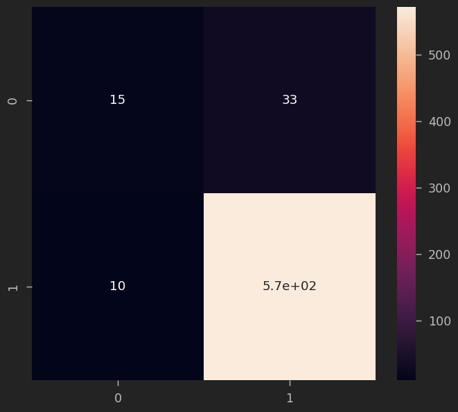

```python
# Predicting the Test set results
y_predict_test = NB_classifier.predict(X_test)
cm = confusion_matrix(y_test, y_predict_test)
sns.heatmap(cm, annot=True)
```

### 5.2.1 Analysis on the matrix visual:

```python
print(classification_report(y_test, y_predict_test))
```

```
              precision    recall  f1-score   support

           0       0.60      0.31      0.41        48
           1       0.95      0.98      0.96       582

    accuracy                           0.93       630
   macro avg       0.77      0.65      0.69       630
weighted avg       0.92      0.93      0.92       630
```

```
              precision    recall  f1-score   support

           0       0.85      0.35      0.50        48
           1       0.95      0.99      0.97       582

    accuracy                           0.95       630
   macro avg       0.90      0.67      0.74       630
weighted avg       0.94      0.95      0.94       630
```

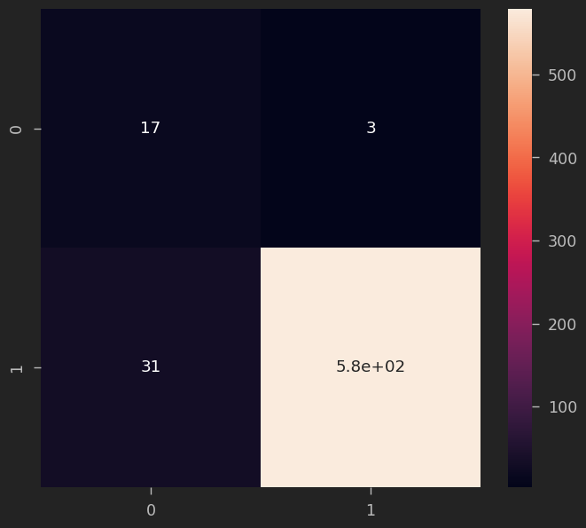

```python
from sklearn.linear_model import LogisticRegression

model = LogisticRegression()
model.fit(X_train, y_train)

y_pred = model.predict(X_test)

cm = confusion_matrix(y_pred, y_test)
sns.heatmap(cm, annot = True)

print(classification_report(y_test, y_pred))
```

```
              precision    recall  f1-score   support

           0       0.79      0.23      0.35        48
           1       0.94      0.99      0.97       582

    accuracy                           0.94       630
   macro avg       0.86      0.61      0.66       630
weighted avg       0.93      0.94      0.92       630
```

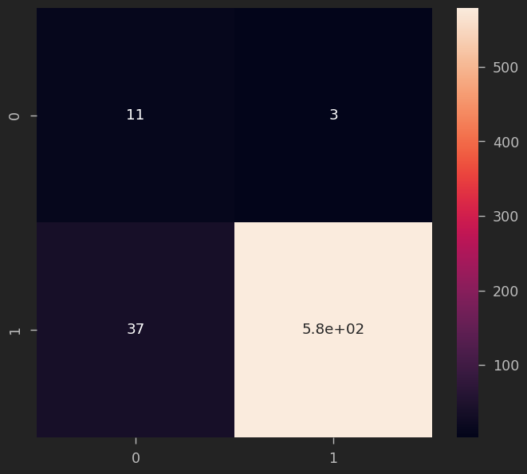

```python
from sklearn.ensemble import GradientBoostingClassifier

model = GradientBoostingClassifier()
model.fit(X_train, y_train)

y_pred = model.predict(X_test)

cm = confusion_matrix(y_pred, y_test)
sns.heatmap(cm, annot = True)

print(classification_report(y_test, y_pred))
```